# Nov. 19 class notes

Lucy Zhang

November 19, 2018

## Scatterplot

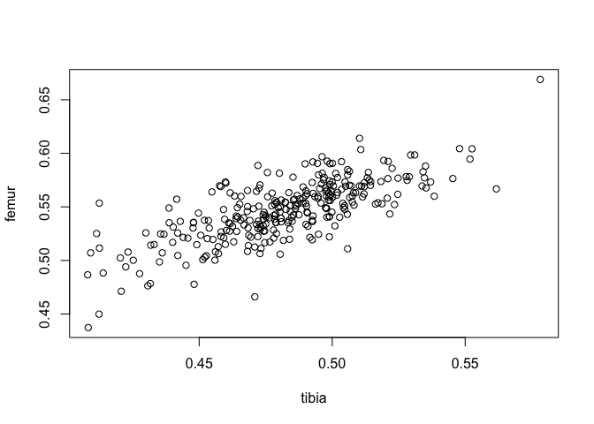

```r
dll_data = read.csv("http://datadryad.org/bitstream/handle/10255/dryad.8377/dll.csv", header=TRUE)

dll_data <- na.omit(dll_data)
dll_data_subset <- dll_data[sample(nrow(dll_data), 300, replace = F),]
plot(femur ~ tibia,
     data = dll_data_subset)
```

Make a nicer-looking plot

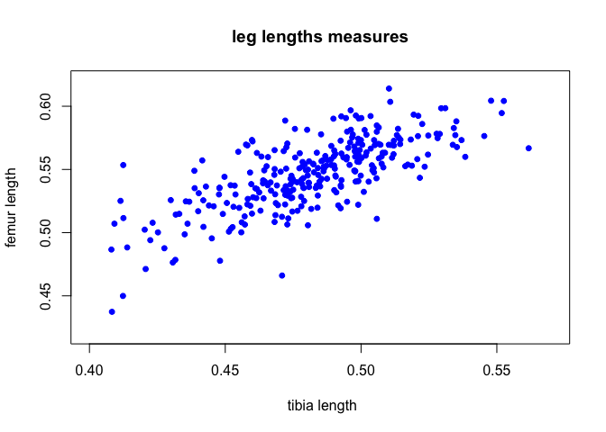

```r
plot(femur ~ tibia,
     pch = 20, # symbol, plot character
     cex = 1.2, # size of symbol, character expand
     col = "blue", # symbol colour
     xlim = c(0.40, 0.57),
     ylim = c(0.42, 0.62),
     xlab = " tibia length",
     ylab = "femur length",
     main = "leg lengths measures",
     data = dll_data_subset)
```

`dev.off()` Close the connection

- `.png, .tiff` are lossless file formats
- `.jpg` are lossy image formats

Small exercise: Q1-Q3

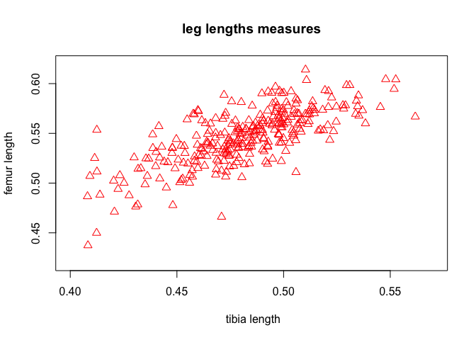

```r
plot(femur ~ tibia,
     pch = 2, # symbol, plot character
     cex = 1.2, # size of symbol, character expand
     col = "red", # symbol colour
     xlim = c(0.40, 0.57),
     ylim = c(0.42, 0.62),
     xlab = " tibia length",
     ylab = "femur length",
     main = "leg lengths measures",
     data = dll_data_subset)
```

Small exercises: Q4 - The SCT data is discrete

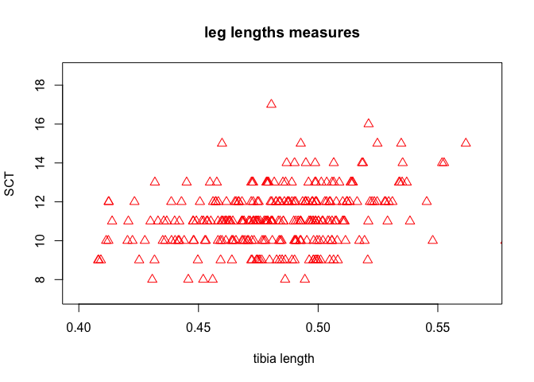

```r
plot(SCT ~ tibia,
     pch = 2, # symbol, plot character
     cex = 1.2, # size of symbol, character expand
     col = "red", # symbol colour
     xlim = c(0.40, 0.57),
     ylim = c((min(SCT)-(0.1*min(SCT))), (max(SCT)+(0.1*max(SCT)))),
     xlab = " tibia length",
     ylab = "SCT",
     main = "leg lengths measures",
     data = dll_data_subset)
```

Separate the data based on shapes, call `temp` as a factor

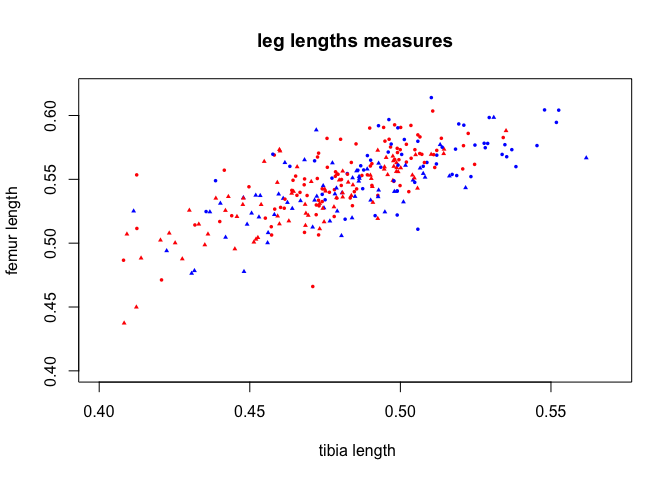

```r
dll_data_subset$temp <- factor(dll_data_subset$temp)
plot(femur ~ tibia,
     pch = c(16,17)[dll_data_subset$temp], # symbol
     cex = 0.5, # size of symbol
     col = c("blue", "red")[dll_data_subset$genotype], # symbol colour
     xlim = c(0.4, 0.57),
     ylim = c(0.4, 0.62),
     xlab = " tibia length",
     ylab = "femur length",
     main = "leg lengths measures",
     data = dll_data_subset)
```

Adding a Legend to your data…

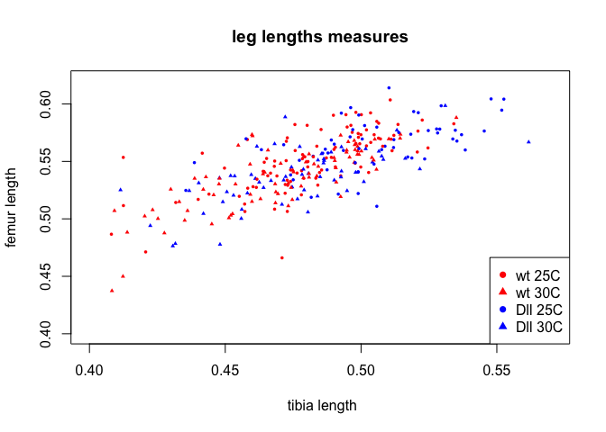

```r
plot(femur ~ tibia,
     pch = c(16,17)[dll_data_subset$temp], # symbol
     cex = 0.5, # size of symbol
     col = c("blue", "red")[dll_data_subset$genotype], # symbol colour
     xlim = c(0.4, 0.57),
     ylim = c(0.4, 0.62),
     xlab = " tibia length",
     ylab = "femur length",
     main = "leg lengths measures",
     data = dll_data_subset)

legend(x = "bottomright",
       legend  = c("wt 25C", "wt 30C", "Dll 25C", "Dll 30C"),
       pch = c(16, 17, 16, 17),
       col = c(rep("red", 2), rep("blue", 2)))
```

This data is overplotted!

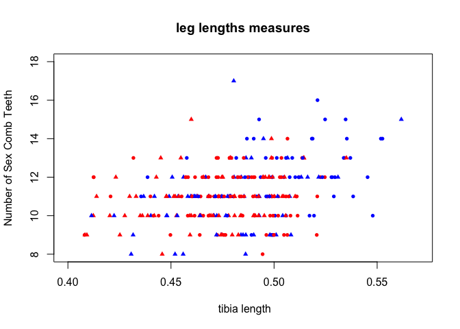

```r
plot(SCT ~ tibia,
     pch = c(16,17)[dll_data_subset$temp], # symbol
     cex = 0.75, # size of symbol
     col = c("blue", "red")[dll_data_subset$genotype], # symbol colour
     xlim = c(0.4, 0.57),
     ylim = c(8, 18),
     xlab = " tibia length",
     ylab = "Number of Sex Comb Teeth",
     main = "leg lengths measures",
     data = dll_data_subset)
```

Adding jitter so your data is easier to see…Change the amount of jitter by adjusting the `factor` parameter insider the `jitter()` function

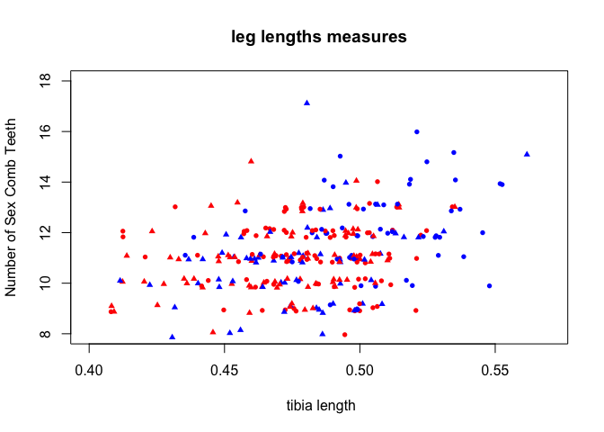

```r
plot(jitter(SCT) ~ tibia,
     pch = c(16,17)[dll_data_subset$temp], # symbol
     cex = 0.75, # size of symbol
     col = c("blue", "red")[dll_data_subset$genotype], # symbol colour
     xlim = c(0.4, 0.57),
     ylim = c(8, 18),
     xlab = " tibia length",
     ylab = "Number of Sex Comb Teeth",
     main = "leg lengths measures",
     data = dll_data_subset)
```

Draw lines on your data

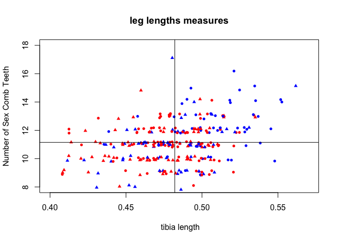

```r
plot(jitter(SCT) ~ tibia,
     pch = c(16,17)[dll_data_subset$temp], # symbol
     cex = 0.75, # size of symbol
     col = c("blue", "red")[dll_data_subset$genotype], # symbol colour
     xlim = c(0.4, 0.57),
     ylim = c(8, 18),
     xlab = " tibia length",
     ylab = "Number of Sex Comb Teeth",
     main = "leg lengths measures",
     data = dll_data_subset)

abline(v = mean(dll_data_subset$tibia))
abline(h = mean(dll_data_subset$SCT))
```

Make fancy `abline()`

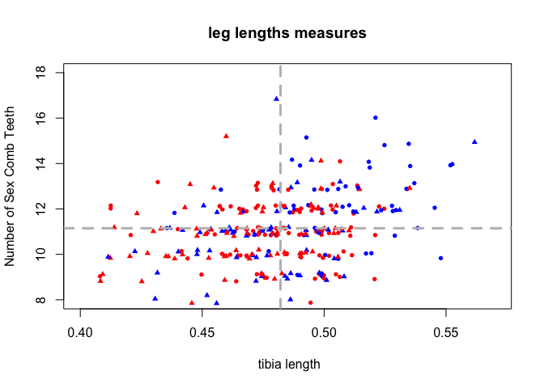

```r
plot(jitter(SCT) ~ tibia,
     pch = c(16,17)[dll_data_subset$temp], # symbol
     cex = 0.75, # size of symbol
     col = c("blue", "red")[dll_data_subset$genotype], # symbol colour
     xlim = c(0.4, 0.57),
     ylim = c(8, 18),
     xlab = " tibia length",
     ylab = "Number of Sex Comb Teeth",
     main = "leg lengths measures",
     data = dll_data_subset)

abline(v = mean(dll_data_subset$tibia),
       lwd = 3, # line width,
       lty = 2, # stippling of line
       col = "grey")

abline(h = mean(dll_data_subset$SCT),
       lwd = 3, lty = 2, col = "grey" )
```

`abline()` is good for making lines or curves through the data: Make a linear regression of the data, then plot the best fit line onto the plot with `abline()`. You can also put many `abline()`s on the plot at once, regressing different parts of the data

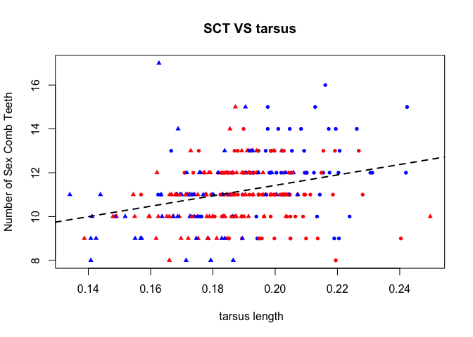

```r
mod1 <- lm(SCT ~ tarsus,
           data = dll_data_subset)

plot(SCT ~ tarsus,
     pch = c(16,17)[dll_data_subset$temp], # symbol
     cex = 0.75, # size of symbol
     col = c("blue", "red")[dll_data_subset$genotype], # symbol colour
     xlab = " tarsus length",
     ylab = "Number of Sex Comb Teeth",
     main = "SCT VS tarsus",
     data = dll_data_subset)

# and then plot based on the model fit.

abline(mod1, lwd = 2, lty = 2)
```

## Boxplot

`notch` parameter gives you approximate visualization of the standard errors

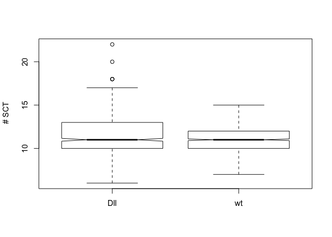

```r
boxplot(SCT ~ genotype,
        data  = dll_data,
        ylab = " # SCT",
        notch = TRUE)
```

`varwidth` parameter adjusts width of the boxes based on the sample sizes

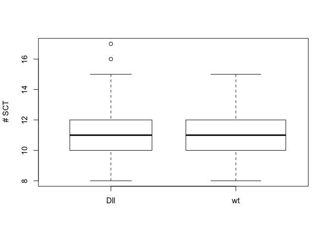

```r
boxplot(SCT ~ genotype,
        data  = dll_data_subset,
        ylab = " # SCT",
        varwidth = TRUE)
```

Add raw points to the boxplot but overplotting the points onto the boxplot, it’s hard to see because there’s no jitter

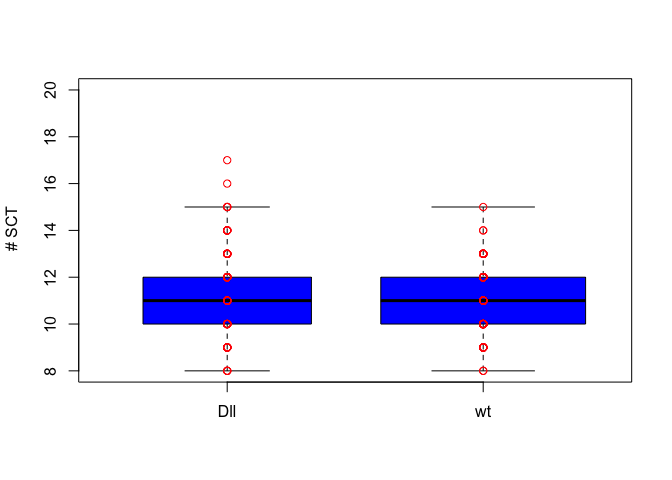

```r
boxplot(SCT ~ genotype,
        data  = dll_data_subset,
        ylab = " # SCT",
        varwidth = TRUE,
        col = "blue",
        outline = FALSE,
        # Suppress observations
        ylim = c(8, 20))

with(dll_data_subset,
     points(y = SCT,
            x = genotype,
            col = "red"))
```

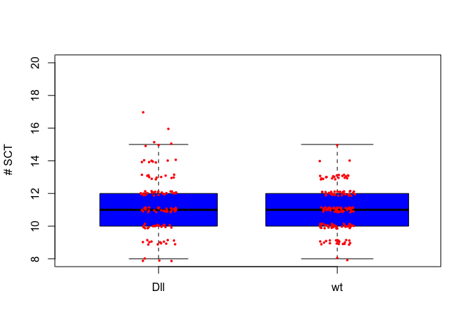

```r
boxplot(SCT ~ genotype,
        data  = dll_data_subset,
        ylab = " # SCT",
        varwidth = TRUE,
        col = "blue",
        outline = FALSE,
        # Suppress observations
        ylim = c(8, 20))

with(dll_data_subset,
     points(y = jitter(SCT, factor = 0.75),
            x = jitter(as.numeric(genotype), factor = 0.5),
            col = "red", pch = 16, cex = 0.5))
```

## Histograms

Make a histogram of the data

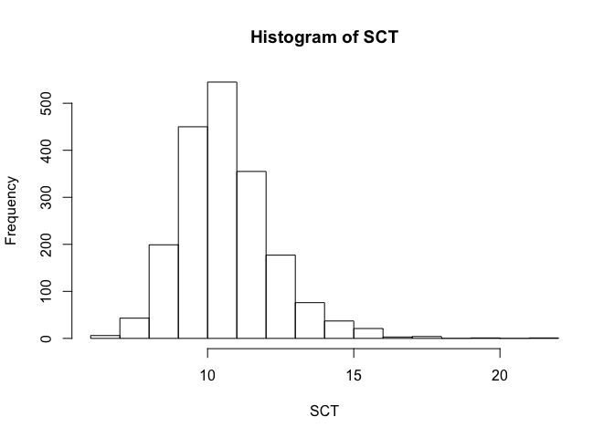

```r
with(dll_data,
     hist(SCT))
```

Change plot to density

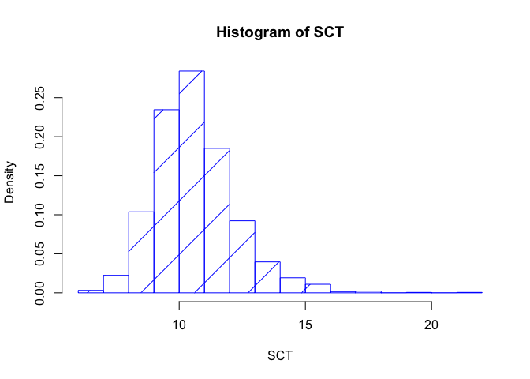

```r
with(dll_data,
     hist(SCT,
          breaks = 12,
          freq = FALSE, # For prob. densities
          density = 2, #lines through bars.
          col = "blue"
          ))
```

Break up the data to make two charts

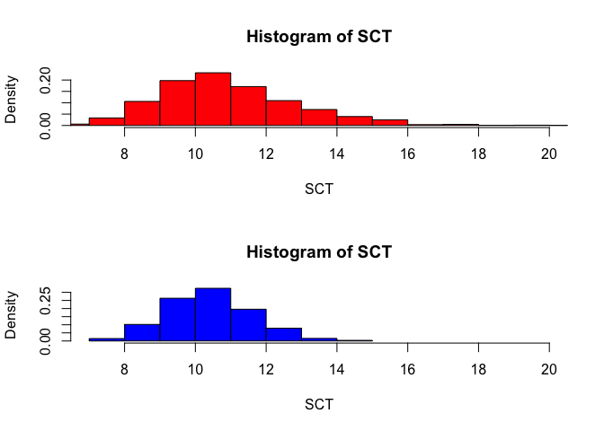

```r
par(mfrow = c(2,1))
# mfrow is setting up number of plots by row

with(dll_data[dll_data$genotype == "Dll",],
     hist(SCT,
          breaks = 13,
          freq = FALSE, # For prob. densities
          col = "red",
          xlim = c(7, 20)
          ))

with(dll_data[dll_data$genotype == "wt",],
     hist(SCT,
          breaks = 9,
          freq = FALSE, # For prob. densities
          col = "blue",
          xlim = c(7, 20)
          ))
```

Overplotting tech

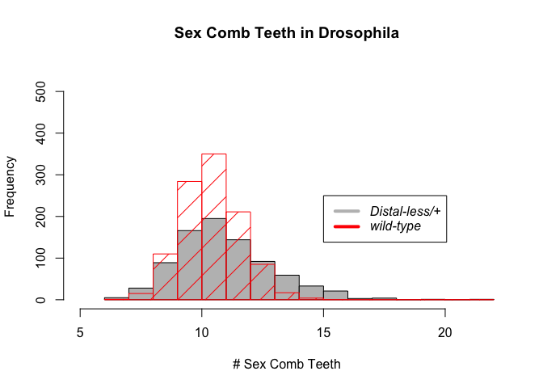

```r
par(mfrow = c(1,1)) # one plotting window
# Generate subsets by genotype
SCT_Dll <- subset(dll_data,
                 subset = genotype =="Dll" )

SCT_wt <- subset(dll_data,
                 subset = genotype =="wt" )

SCT <- dll_data$SCT
# First we will draw the histogram

hist(SCT_Dll$SCT,
     col= "grey",
  # Sometimes the default breaks are not so good, so here we use a sequence from lowest observed SCT to highest
     breaks = seq(min(SCT), max(SCT)), # sets up breaks for histograms

  # Since we are planning on displaying two data sets, we need to make sure our y axis goes high enough
  # below we compute the tables for # of SCT for each subset
      ylim = c(0, max( c(table(SCT), table(SCT)))),  # sets up the maximum

  # Ditto for  the x axis
     xlim = c(5, max(SCT)),

     main = "Sex Comb Teeth in Drosophila",

     xlab = " # Sex Comb Teeth ",
     border = "black") # this is where the call to hist ends!

# Now we add on a second histogram
hist(SCT_wt$SCT,
     col= "red",
     density = 4,  # number of "crossing" lines
     border = "red",  # The border colour for the histogram
     breaks=seq(min(SCT), max(SCT)),
     add = TRUE)

#Perhaps a legend would also be useful here

legend(x = 15, # The beginning x coordinate for the legend
       y = 250,

       # Sometimes for our text we want to use italics or generate a mathematical expression. we use expression()
       # for more details ?text or ?plotmath
       legend = c( expression(italic("Distal-less/+")),
          expression(italic("wild-type"))),

       col = c("grey", "red"),  # Setting up the colours for the legend box
       lwd=4)   # lwd sets the line width
```

## Advanced examples

Make some random data, making a new data frame and predict new data using `predict()`, into a new data set

```r
x <- 1:50
y <- rnorm(n = length(x), mean = (2 + (0.8*x)), sd= 4)

model_1 <- lm(y ~ x)
new <- data.frame(x = seq(min(x), max(x), 1))
pred <- predict(model_1, newdata = new, interval = "confidence")
```

Plot the data

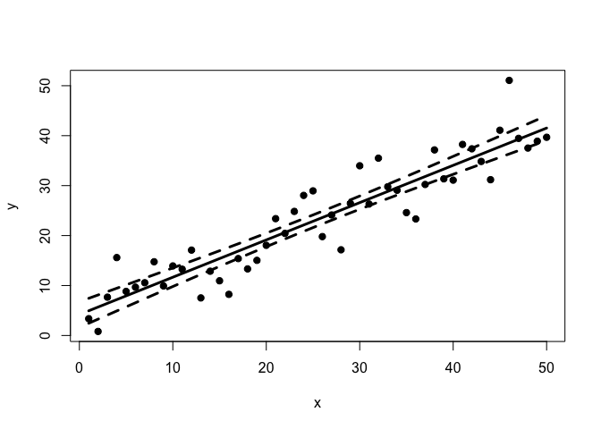

```r
plot(y ~ x, pch = 20, cex = 1.5)
lines(x = new[,1], y = pred[,1], lwd = 3) # this would be the same as abline(model.1)
lines(x = new[,1], y = pred[,3], lwd = 3, lty = 2)
lines(x = new[,1], y = pred[,2], lwd = 3, lty = 2)
```

Way to put multiple lines, makes a matrix of lines (mathlines)

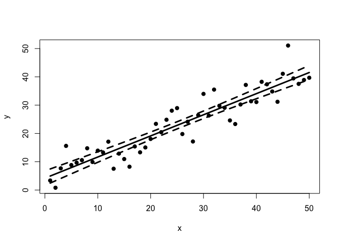

```r
plot(y ~ x, pch = 20, cex = 1.5)
matlines(x = new[,1], y = pred[,1:3], lwd=c(3,3,3), lty=c(1,2,2), col = 1)
```

Plot confidence level as a shaded region

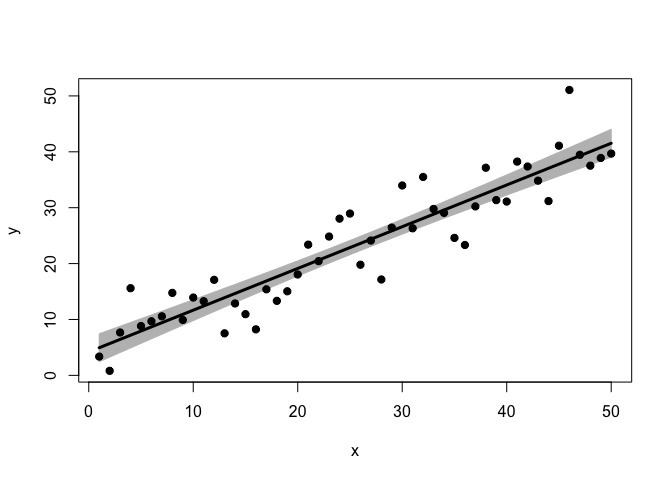

```r
plot(y ~ x, pch= 20, type = "n")

polygon(x = c(1:nrow(new), nrow(new):1),
    y = c(pred[,2], rev(pred[,3])),
    col="grey", border = "grey")

lines(x = new[,1], y = pred[,1], lwd = 3)
# And the data
points(y ~ x, pch = 20, cex = 1.5)
```

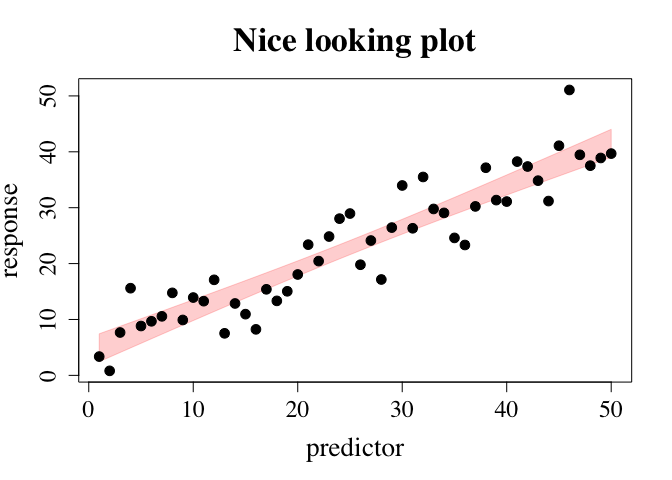

```r
plot(y ~ x, type = "n",
    xlab = "predictor", ylab = "response", main = "Nice looking plot",
    cex.lab = 1.7, cex.axis = 1.5, cex.main = 2.1,
    family = "serif", pch = 20)

polygon(x = c(1:nrow(new), nrow(new):1),
    y = c(pred[,2], rev(pred[,3])),
    col= "#fe000032", border = "#fe000032")

points(y ~ x, pch = 20, cex = 2)
```